# A Git workflow with the terminal

In this guide, we will work on a cook book project using Git and the terminal. We will start going through all the steps for an individual project (you’re working on the cook book alone) and then we will see how to collaborate with others.

# Preparations

To follow this guide you need:

- Git installed
- GitHub Desktop installed
- A GitHub account connected to your GitHub Desktop program

Check out the course preparations if you miss anything from this list.

All commands that you see in the following guide, have to be typed in the terminal and then you have to hit Enter to execute the command. If you are on Windows, I recommend to use the Git Bash terminal that comes with the Git installation (Just search for “Git Bash” in the Windows search bar). On MacOS/Linux, you can just use the standard terminal.

## A word on authentication

You might ask yourself: why do I need GitHub Desktop if we are using the terminal? The reason is that GitHub Desktop makes it much easier to set up the connection between your local machine and GitHub. Authentication is handled for you using OAuth. During this process, GitHub Desktop securely stores your credentials in your operating system’s native credential store (Windows: Windows Credential Manager, macOS: Keychain Access, Linux: libsecret/gnome-keyring, depending on the distro).

Because Git itself can read from these credential stores, other Git clients (e.g. command line, RStudio, VS Code) can also use the same authentication. This works as long as you are using HTTPS URLs for your repositories.

If you prefer to use SSH for authentication (for automation, servers, or personal preference), you need to set up SSH keys and add them to GitHub. See here for a guide on how to do this.

## Configure Git

Git needs to know who you are in order to sign your commits correctly. If you already set up GitHub Desktop, you might already have the minimal Git configuration ready.

The Git configuration can be set locally (just for the current repo) or globally (default for all repos without local configuration). Here, we just set a global configuration for all repositories.

To check if you already have a configuration run

```bash
git config --global -l
```

If you don’t see a `user.name` or `user.email` or get a message, that the `.gitconfig` file does not exist, run the following to configure:

```bash
git config --global user.name "<your_user_name>"
git config --global user.email "<your_user_email>"
```

Use the user name and email that you also use for your GitHub account.

# A Git workflow for your individual project

## Step 1: Initialize a new repository

A new Git project can be started in an empty folder or in a folder that already contains files. For this example, first create a new folder `cookBook` somewhere on your computer.

After opening the terminal (Git Bash on Windows, Terminal on macOS/Linux), move into the folder you created:

```bash
cd cookBook # go into the folder
cd ..       # go back one level
```

You might have to chain multiple `cd` commands to get to the right location.

**Tip**

On Windows, you can also right-click the project folder and choose **Git Bash Here**. (Windows 11: first click **Show more options**.)

[figure not shown]

Your terminal should now show the path of your cookBook folder, like this:

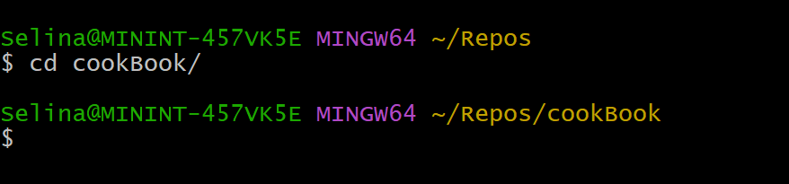

Now you can initialize a new Git repository in this folder by running:

```bash
git init
```

You should see a message telling you that the repository was initialized. In Git Bash, you can now also see that you are in a Git repository, because the branch name is indicated in blue behind the folder path:

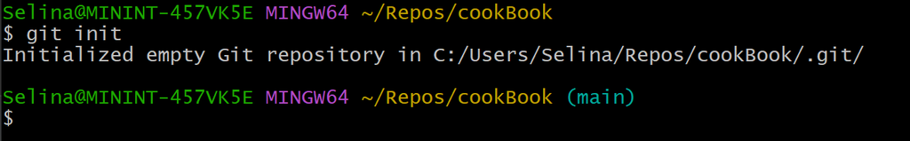

You can also check that a new hidden folder `.git` was created in your cookBook folder. To print all files including hidden ones:

```bash
ls -a
```

and you should see the `.git` folder:

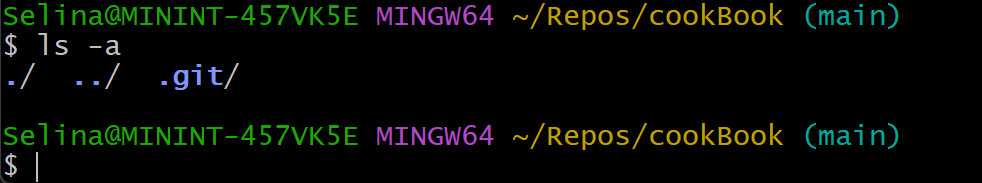

## Step 2: Add the first recipe

Open your cook book project in the file explorer.

Add a new text file with your favorite recipe (Let’s assume it’s pie). Create a file called pie.txt and add the recipe text below to it:

```markdown
Ingredients:
150 g butter
200 g sugar
3 eggs
350 g flour
1 pkg. baking powder
juice from one lemon

Mix everything together and put in the oven
for 45 mins at 200 °C.
```

Save the file and switch back to the terminal.

### Explore the changes to your repository with `git status`

Check the current status of your Git repository by running

```bash
git status
```

This will show you that `pie.txt` is a new and untracked file:

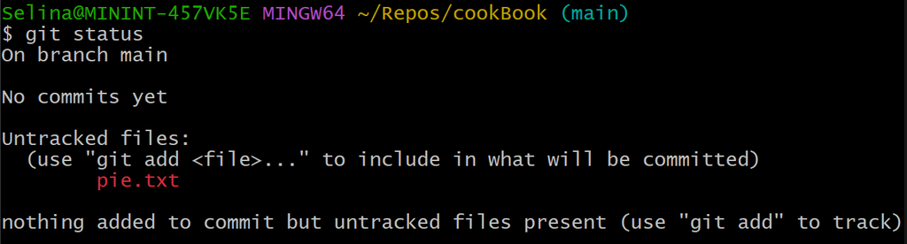

The message already tells you what to do next: You can stage the file to be included in the next commit.

## Step 3: Stage the new file

To stage the changes to `pie.txt` (i.e. the creation of the file) run

```bash
git add pie.txt
```

This means that now `pie.txt` is ready to be committed.

**TipStage multiple files at once**

If you have multiple files, you want to stage, you can do this in one step with

```bash
git add .
```

The `.` stands for the current folder, so this stages all changes in your project (including hidden files like `.gitignore`).

Now you can check the repository status with `git status` again to confirm this:

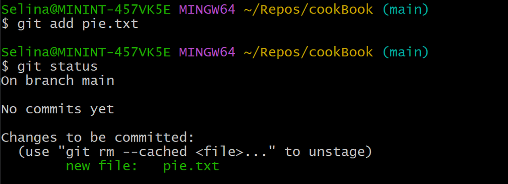

Git now tells you, that `pie.txt` is now ready to be committed.

## Step 4: Make a commit

To commit all changes that are staged, run

```bash
git commit
```

Now your default text editor will open, and you can add a commit message and an optional description (this is all the text after an empty line).

For me this opens VS Code and it looks like this:

[figure not shown]

When you are done writing the commit message, save the file and close the editor.

Look how the status of your repository has changed with

```bash
git status
```

Now you don’t have any more uncommitted changes in your project:

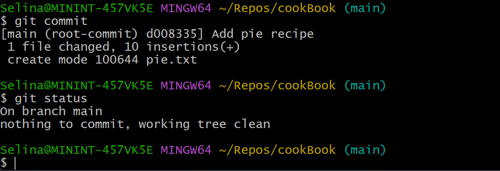

**TipGood commit messages**

There are guidelines on how to write good commit messages. This becomes especially important when collaborating. Have a look [here](https://cbea.ms/git-commit/) for some guidelines on how to write good commit messages and why this is important.

### Look at the commit history

To look at the history of your commits, run

```bash
git log
```

This will show you all commits in reverse chronological order (most recent first). You can also see who did the commit, when it was done and the commit message.

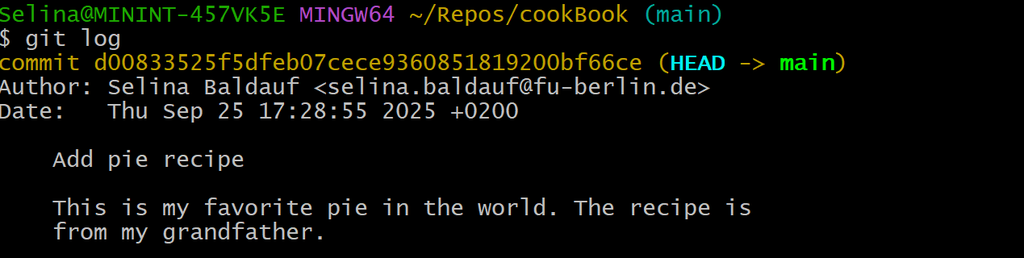

If you want a shorter summary, you can also use

```bash
git log --oneline
```

## Step 5: Share your project on GitHub

Now we want to share our cook book with the world (or our collaborators), so we want to publish it on GitHub.

So what we want to do is connect our local repository with a remote repository on GitHub.

In the terminal, this is slightly more complicated than with GitHub Desktop.

Go to the [GitHub website](https://github.com/), log into your account and click on the green **New** button on the left of the start page:

[figure not shown]

Enter a repository name (e.g. `cookBook`), select if it should be private or public and add a description if you like. Important: Do not create the repository with a README or license file. It should look like this:

[figure not shown]

GitHub will now bring you to the newly created repository. Since the repository is empty, it will show you instructions on how to add files to it. We need to follow the instructions under “…or push an existing repository from the command line”:

[figure not shown]

So switch over to the terminal and run the three commands shown there one after another:

```bash
git remote add origin https://github.com/selinaZitrone/cookBook.git # connect the remote
git branch -M main          # rename the local branch to main
git push -u origin main     # push the local main branch to Github
```

(Of course replace the URL with the URL of your own repository.)

Now you can head over to GitHub and refresh the page of your repository. You should now see your `pie.txt` file there:

[figure not shown]

# Collaboration workflows

Git and GitHub are perfect for collaboration. Let’s assume your friend also has a cook book project on GitHub and you want to help work on their cook book.

If you want to test this workflow by collaborating with yourself, you can just skip step 1 and do the other steps with your own instead of your friend’s cook book.

## Add collaborators on GitHub repository

To collaborate, your friend needs to add you to their GitHub project. On the GitHub webpage of the repository, they can go to **Settings -> Collaborators -> Add people**:

[figure not shown]

Then add people using their GitHub user name. The invited person will get an invitation email for the repository. Accept this invitation and you are now a collaborator on your friend’s project.

## Step 1: Clone a remote repository

Before you can start working on your friend’s cook book, you need to clone their repository. This means getting your own local copy of the cook book.

To clone a repository, you need to know the repositories address. You can find and copy it by clicking on the green code button on GitHub (in this example, I just clone my own repository as a demonstration):

[figure not shown]

Make sure you select the HTTPS address (unless you set up SSH keys, then you can also use the SSH address).

Open the terminal, navigate to a location where you want to clone the project and run:

```bash
git clone https://github.com/selinaZitrone/cookBook.git
```

(Of course replace the address with the repository you actually want to clone).

After cloning, I navigate into the newly created folder using

```bash
cd cookBook # or your friend's repository name
```

You can see in the last line that I am in a Git repository, because the branch name is indicated in blue:

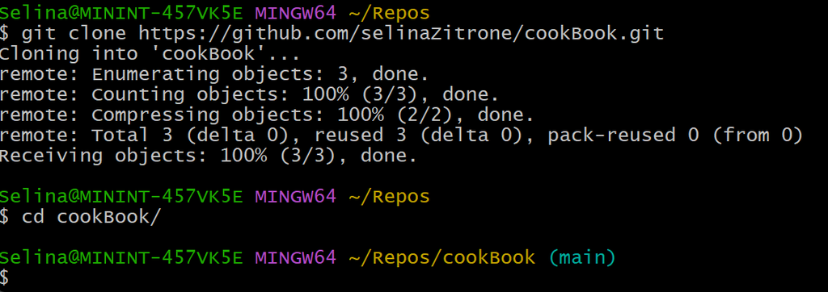

## Step 2: Create a new branch

Let’s say, you want to add a vegan pie recipe to your friend’s cook book. To use the collaboration workflow discussed in the lecture, you need to create a new branch to work on.

To create a new branch with the name “add_vegan_pie” just run

```bash
git branch add_vegan_pie
```

After the branch is created, you need to switch to it with

```bash
git switch add_vegan_pie
```

To see which branch you are currently on, run

```bash
git branch
```

The green, highlighted branch is the one you are currently on (but you can also see it in the blue branch name next to the path).

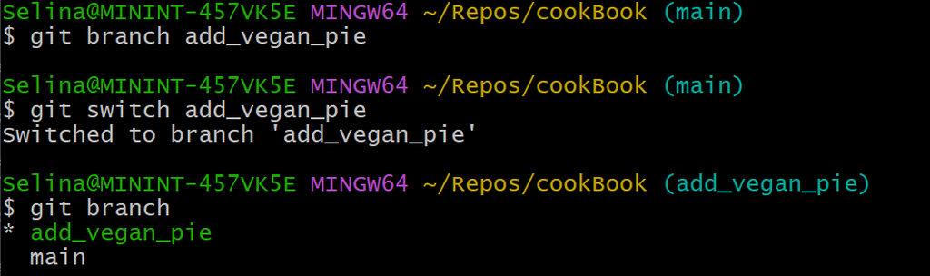

Now you can start working on this branch. Add a file for the vegan pie and then stage and commit them like you are used to (see steps 2-4 in the previous section).

## Step 3: Publish and push your branch

To share your branch with the vegan pie recipe with your friend, you need to push the branch to the remote repository on GitHub. This works just like with the main branch using `git push`.

But the first time you push a new branch, you need to specify the upstream by running:

```bash
git push --set-upstream origin add_vegan_pie
```

Now your branch is pushed to GitHub and you can do a pull request.

## Step 4: Create a pull request

See here for a guide on how to create a pull request to ask your friend to integrate your recipe into their cookbook.

# Other things to try

## Add a gitignore file

- Put a pdf file in your repo
- Look at `git status`: It should now show that you can commit the pdf file. But for this example, we want to ignore it.
- Add a `.gitignore` file to your project

**NoteCreate a `.gitignore` file on Windows**

On Windows, you cannot create a file without a file name. So the Windows explorer will complain if you try to create a file with only the file ending .gitignore. One way around this is to use the terminal. In Git bash, just run

```bash
touch .gitignore
```

to create a gitignore file

- Ignore pdf files
  - Add a line with the pattern `*.pdf` to your gitignore file and save it
- Now look at `git status` again. If everything worked, you should not see the changes in the pdf anymore, because it was ignored.

## Compare commits

- Change some text in pie.txt
- stage it with `git add`
- look at the diff with `git diff --staged`
- commit the changes
- compare this commit to the previous one with
  - `git diff HEAD^ HEAD`
- push to origin

## Merge your new branch with the `main`

If you want to locally integrate changes you did in a separate branch into the main branch, you first need to switch back to the main branch:

```bash
git switch main
```

Now merge the commits from your branch with

```bash
git merge add_vegan_pie
```

Check if it actually worked with

```bash
git log
```